# IFN704

Paramita Parinyanupap

29/08/2021

# Data

Load necessary Library and read the data in

```r
library(haven)
library(dplyr)
library(ggplot2)
library(foreign)
library(nnet)
library(reshape2)
library(Hmisc)
library(MASS)
library(stringr)
library(rcompanion)

data17 <- read_spss("spss1/Combined q170c.sav")
data17 <- data17 %>% rename_all(~stringr::str_replace(., "q", ""))
data17a <- data17[c("gh9h", "wsce", "bncall", "jbhruc", "hgage1", "edhigh1", "hgsex1", "gh1", "mrcurr")]

colnames(data17a)
```

```
## [1] "gh9h"    "wsce"    "bncall"  "jbhruc"  "hgage1"  "edhigh1" "hgsex1"
## [8] "gh1"     "mrcurr"
```

```r
df2 <- rename(data17a, c(
    "happiness" = "gh9h",
    "wage" = "wsce",
    "government_allowances" = "bncall",
    "hour" ="jbhruc",
    "age" = "hgage1",
    "education" ="edhigh1",
    "gender" ="hgsex1",
    "health" ="gh1",
    "marital_status" ="mrcurr")
)

colnames(df2)
```

```
## [1] "happiness"             "wage"                  "government_allowances"
## [4] "hour"                  "age"                   "education"
## [7] "gender"                "health"                "marital_status"
```

```r
dim(df2)
```

```
## [1] 23415     9
```

```r
# check percentage of missing value
colMeans(is.na(df2))
```

```
##             happiness                  wage government_allowances
##          3.191117e-01          2.647021e-01          2.525304e-01
##                  hour                   age             education
##          5.272261e-01          4.270767e-05          2.495836e-01
##                gender                health        marital_status
##          4.270767e-05          3.198377e-01          2.496263e-01
```

```r
# convert data type
library(rccdates)
df2 <- within(df2, {
  gender <- factor(gender, levels = 1:2, labels = c("male", "female"))
  education <- factor(education, levels = c(9, 8, 5, 4, 3, 2, 1), labels = c("Year 11 or below", "Year 12", "Cert III or IV", "Adv Diploma, diploma", "Bachelor or honours","Grad diploma, grad certificate", "Postgrad - masters or doctorate"))
  happiness <- factor(happiness, levels = 6:1, labels = c("None of the time", "A little of the time", "Some of the time", "A good bit of the time", "Most of the time", "All of the time"))
  health <- factor(health, level = 5:1, labels = c("Poor", "Fair", "Good", "Very good", "Excellent"))
})


df2$marital_status <- factor(df2$marital_status, levels = c(1,2,3,4,5,6), labels = c("Married", "Defacto", "Seperated", "Divorced", "Widowed", "Single"))

df2 <- na.omit(df2)

# filter age within 18 and 65 -> labour force
df2 <-df2 %>%
  filter(age > 18 & age < 65)


dim(df2)
```

```
## [1] 9099    9
```

```r
summary(df2)
```

```
##                   happiness         wage       government_allowances
##  None of the time      :  68   Min.   :    0   Min.   :  0.000
##  A little of the time  : 439   1st Qu.:  575   1st Qu.:  0.000
##  Some of the time      :1316   Median : 1015   Median :  0.000
##  A good bit of the time:1959   Mean   : 1174   Mean   :  4.964
##  Most of the time      :4594   3rd Qu.: 1550   3rd Qu.:  0.000
##  All of the time       : 723   Max.   :11873   Max.   :750.000
##
##       hour             age                                  education
##  Min.   :  0.00   Min.   :19.00   Year 11 or below               :1350
##  1st Qu.: 30.00   1st Qu.:32.00   Year 12                        :1481
##  Median : 38.00   Median :44.00   Cert III or IV                 :2263
##  Mean   : 36.49   Mean   :42.74   Adv Diploma, diploma           : 962
##  3rd Qu.: 45.00   3rd Qu.:53.00   Bachelor or honours            :1727
##  Max.   :100.00   Max.   :64.00   Grad diploma, grad certificate : 625
##                                   Postgrad - masters or doctorate: 691
##     gender           health       marital_status
##  male  :4600   Poor     : 100   Married  :4379
##  female:4499   Fair     : 868   Defacto  :1899
##                Good     :3251   Seperated: 222
##                Very good:3657   Divorced : 424
##                Excellent:1223   Widowed  :  63
##                                 Single   :2112
##
```

## Data Description

```r
summary(df2$education)
```

```
##                Year 11 or below                         Year 12
##                            1350                            1481
##                  Cert III or IV            Adv Diploma, diploma
##                            2263                             962
##             Bachelor or honours  Grad diploma, grad certificate
##                            1727                             625
## Postgrad - masters or doctorate
##                             691
```

I choose the variables from HILDA dataset, which includes wage, government allowances (bncall), weekly work hour, age, education (edhigh1), and happiness. The detail of variable - wage(wsce) is currently weekly gross wages and salary, all jobs, includes estimated from net($) [weighted topcode] - government_allowances (bncall) is the current weekly Australian Government Allowances ($) - hour: Hours per week usually worked in all jobs - age - gender [1] Male [2] Female - education (qedhigh1) is history of highest education level achieved [10] undetermined [1] Postgrad - masters or doctorate [2] Grad diploma, grad certificate [3] Bachelor or honours [4] Adv diploma, diploma [5] Cert III or IV [8] Year 12 [9] Year 11 or below

- health (gh1) is self-assessed health [-4] refused/ not stated [-5] multiple response SCQ [-8] No SCQ [1] Excellent [2] Very good [3] Good [4] Fair [5] Poor
- happiness (gh9h) is A9h Mental Health: Been a happy person Answering in scale “Have you been a happy person?” [-4] refused/ not states [-5] multiple response SCQ [-8] no SCQ [1] All of the time [2] Most of the time [3] A good bit of the time [4] Some of the time [5] A little of the time [6] None of the time
- country of birth (ancob) in which country were you born? change the value of interest to Australian = 1 and the rest = 0 the same value for all waves but indifferent variable for wave 1 aancob, wave 2 bancob
- employment contract - current job (jbmcnt) [-1] Not asked [-4] refused/not stated [1] Employed on a fixed-term contract [2] Employed on a casual basis [3] Employed on a permanent or ongoing basis [8] Other
- E36a total pay satisfaction (jbmssec)
- job security satisfaction (jbmssec)
- work satisfaction (jbmswrk)
- the hour of work satisfaction (jbmshrs)
- year of survey display in wave
- xwaveid = id for cross

marital status 1 Legally married 2 De facto 3 Separated 4 Divorced 5 Widowed 6 Never married and not de facto

## 1. Data Exploration

Continuous variable hour, wage, government_allowances, age

Checking normal distribution - normal - wage is right skews

```r
# Boxplot
colnames(df2)
```

```
## [1] "happiness"             "wage"                  "government_allowances"
## [4] "hour"                  "age"                   "education"
## [7] "gender"                "health"                "marital_status"
```

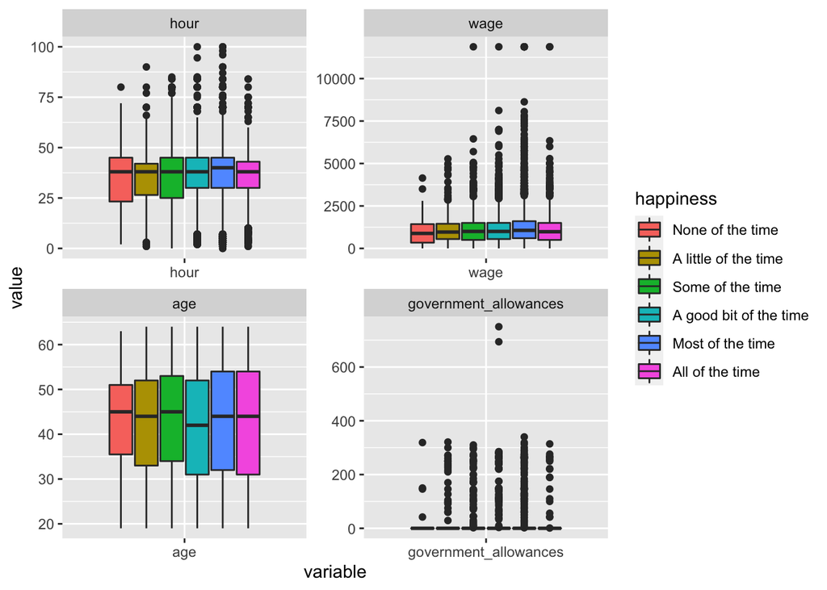

```r
df.l <- df2[c("hour", "wage", "age", "government_allowances","happiness")]
df.m <- melt(df.l, id.var = "happiness")

p <- ggplot(data = df.m, aes(x = variable, y = value)) + geom_boxplot(aes(fill = happiness))
p + facet_wrap(~ variable, scales = "free")
```

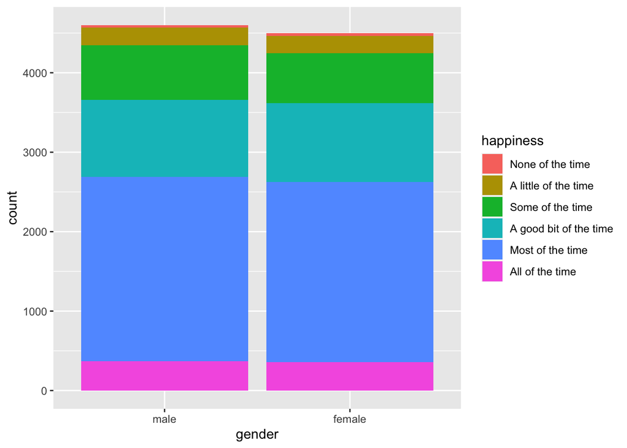

```r
par(mfrow=c(2,2))
ggplot(df2, aes(x = gender, fill = happiness)) + geom_bar(position = "stack")
```

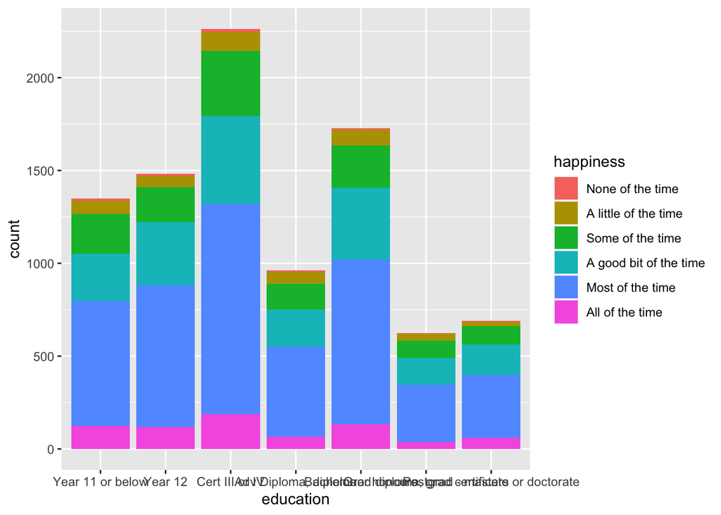

```r
ggplot(df2, aes(x = education, fill = happiness)) + geom_bar(position = "stack")
```

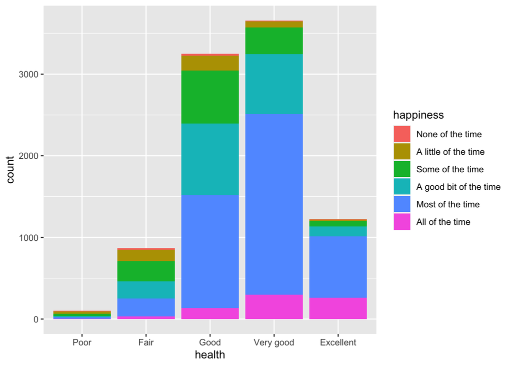

```r
ggplot(df2, aes(x = health, fill = happiness)) + geom_bar(position = "stack")
```

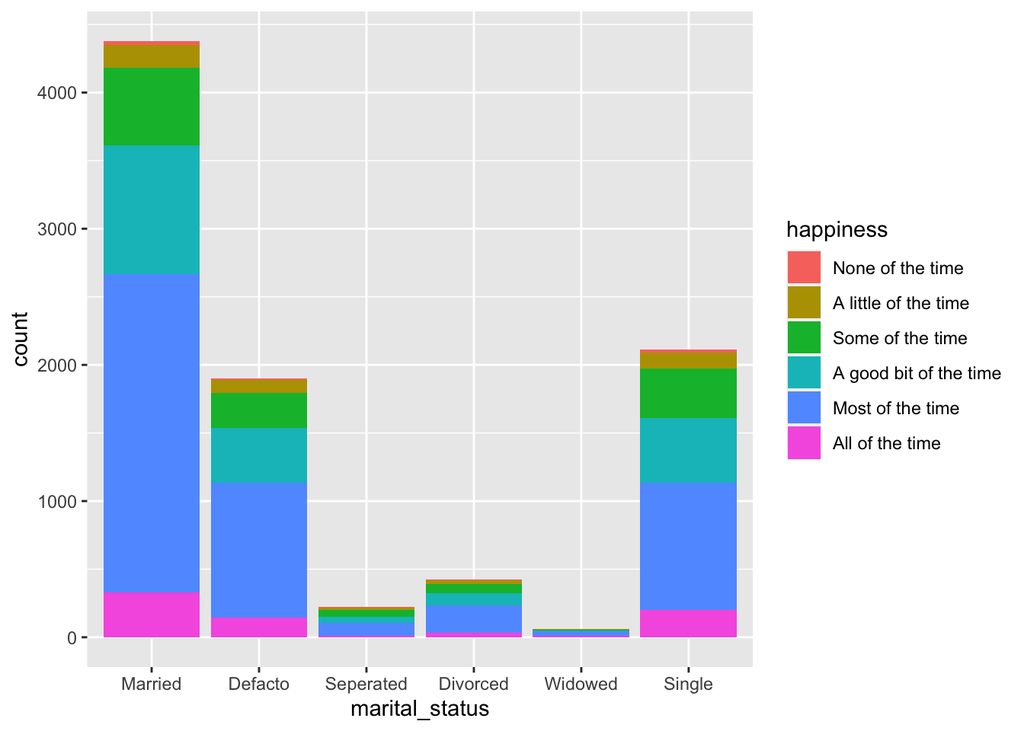

```r
ggplot(df2, aes(x = marital_status, fill = happiness)) + geom_bar(position = "stack")
```

```r
library(corrplot)
library(Hmisc)
df3 <- df2[c("hour", "wage", "government_allowances")]
df3.cor <- cor(df3, method = c("spearman"))
df3.cor
```

```
##                             hour       wage government_allowances
## hour                   1.0000000  0.5459186            -0.2077328
## wage                   0.5459186  1.0000000            -0.1950635
## government_allowances -0.2077328 -0.1950635             1.0000000
```

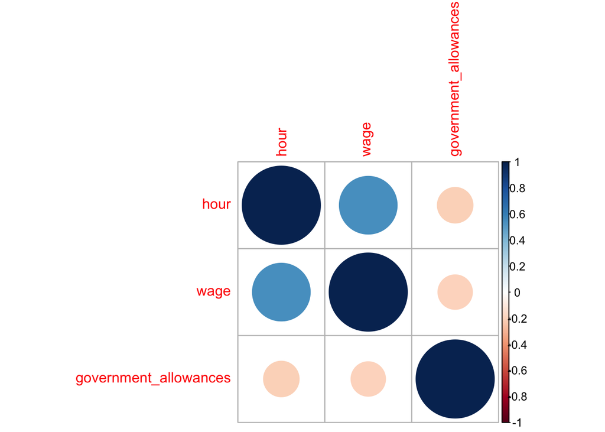

```r
corrplot(df3.cor)
```

Correlation matrix shows that there is no multicollinearity problem. However, hour and wage are almost highly correlated.

## 2. Data Partition

```r
ind <-sample(2, nrow(df2), replace = TRUE, prob = c(0.7, 0.3))
train <- df2[ind == 1,]
test <- df2[ind == 2,]
```

# Model

```r
library(MASS)
library(Hmisc)
orderlog <- polr(happiness ~ wage + government_allowances + hour + age + education + gender + health + marital_status, data = train, Hess = TRUE)
summary(orderlog)
```

```
## Call:
## polr(formula = happiness ~ wage + government_allowances + hour +
##     age + education + gender + health + marital_status, data = train,
##     Hess = TRUE)
##
## Coefficients:
##                                               Value Std. Error  t value
## wage                                      3.718e-05  3.569e-05   1.0417
## government_allowances                    -1.067e-03  7.871e-04  -1.3552
## hour                                      2.836e-03  1.938e-03   1.4638
## age                                       5.465e-03  1.828e-03   2.9900
## educationYear 12                         -2.538e-01  5.956e-02  -4.2622
## educationCert III or IV                  -2.303e-01  5.154e-02  -4.4688
## educationAdv Diploma, diploma            -4.074e-01  6.757e-02  -6.0293
## educationBachelor or honours             -4.370e-01  5.425e-02  -8.0564
## educationGrad diploma, grad certificate  -6.945e-01  7.587e-02  -9.1535
## educationPostgrad - masters or doctorate -4.867e-01  7.382e-02  -6.5934
## genderfemale                              4.300e-02  4.726e-02   0.9098
## healthFair                                7.489e-01  6.322e-02  11.8471
## healthGood                                1.618e+00  4.108e-02  39.3860
## healthVery good                           2.563e+00  4.022e-02  63.7268
## healthExcellent                           3.586e+00  6.068e-02  59.0991
## marital_statusDefacto                    -8.718e-02  6.248e-02  -1.3952
## marital_statusSeperated                  -5.149e-01  1.915e-02 -26.8829
## marital_statusDivorced                   -1.567e-01  1.110e-01  -1.4116
## marital_statusWidowed                    -8.401e-02  2.419e-03 -34.7320
## marital_statusSingle                     -4.025e-01  6.137e-02  -6.5591
##
## Intercepts:
##                                         Value     Std. Error t value
## None of the time|A little of the time     -3.0437    0.0105  -290.1996
## A little of the time|Some of the time     -1.0031    0.0991   -10.1238
## Some of the time|A good bit of the time    0.5667    0.0987     5.7410
## A good bit of the time|Most of the time    1.7528    0.0995    17.6239
## Most of the time|All of the time           4.8729    0.1103    44.1701
##
## Residual Deviance: 16009.32
## AIC: 16059.32
```

```r
logLik(orderlog)
```

```
## 'log Lik.' -8004.659 (df=25)
```

```r
# p-Value Calculation
m1.coef <- data.frame(coef(summary(orderlog)))
m1.coef$pval = round((pnorm(abs(m1.coef$t.value), lower.tail = FALSE) * 2), 2)
m1.coef
```

|  | Value | Std..Error | t.value | pval |
| --- | --- | --- | --- | --- |
| wage | 3.718254e-05 | 3.569321e-05 | 1.0417257 | 0.30 |
| government_allowances | -1.066634e-03 | 7.870856e-04 | -1.3551694 | 0.18 |
| hour | 2.836450e-03 | 1.937684e-03 | 1.4638353 | 0.14 |
| age | 5.465128e-03 | 1.827782e-03 | 2.9900332 | 0.00 |
| educationYear 12 | -2.538406e-01 | 5.955614e-02 | -4.2622068 | 0.00 |
| educationCert III or IV | -2.303276e-01 | 5.154105e-02 | -4.4688195 | 0.00 |
| educationAdv Diploma, diploma | -4.074022e-01 | 6.757048e-02 | -6.0292922 | 0.00 |
| educationBachelor or honours | -4.370231e-01 | 5.424543e-02 | -8.0564038 | 0.00 |
| educationGrad diploma, grad certificate | -6.945001e-01 | 7.587275e-02 | -9.1534856 | 0.00 |
| educationPostgrad - masters or doctorate | -4.867259e-01 | 7.382059e-02 | -6.5933626 | 0.00 |

[output cut: 15 more lines]

```r
# export the model p-value data
library(stargazer)
stargazer(orderlog, type = "text", out = "orderlog.txt")
```

```
##
## ====================================================================
##                                              Dependent variable:
##                                          ---------------------------
##                                                   happiness
## --------------------------------------------------------------------
## wage                                               0.00004
##                                                   (0.00004)
##
## government_allowances                              -0.001
##                                                    (0.001)
##
## hour                                                0.003
##                                                    (0.002)
##
## age                                               0.005***
##                                                    (0.002)
##
## educationYear 12                                  -0.254***
##                                                    (0.060)
##
## educationCert III or IV                           -0.230***
##                                                    (0.052)
##
## educationAdv Diploma, diploma                     -0.407***
##                                                    (0.068)
##
## educationBachelor or honours                      -0.437***
##                                                    (0.054)
##
## educationGrad diploma, grad certificate           -0.695***
##                                                    (0.076)
##
## educationPostgrad - masters or doctorate          -0.487***
##                                                    (0.074)
##
## genderfemale                                        0.043
##                                                    (0.047)
##
## healthFair                                        0.749***
```

[output cut: 15 more lines]

```
##                                                    (0.019)
##
## marital_statusDivorced                             -0.157
##                                                    (0.111)
##
## marital_statusWidowed                             -0.084***
##                                                    (0.002)
##
## marital_statusSingle                              -0.403***
##                                                    (0.061)
##
## --------------------------------------------------------------------
## Observations                                        6,382
## ====================================================================
## Note:                                    *p<0.1; **p<0.05; ***p<0.01
```

```r
# odd ratio
ci <- confint.default(orderlog)
exp(cbind(OR = coef(orderlog), ci))
```

```
##                                                  OR      2.5 %     97.5 %
## wage                                      1.0000372  0.9999672  1.0001071
## government_allowances                     0.9989339  0.9973941  1.0004761
## hour                                      1.0028405  0.9990391  1.0066563
## age                                       1.0054801  1.0018845  1.0090886
## educationYear 12                          0.7758155  0.6903418  0.8718720
## educationCert III or IV                   0.7942733  0.7179565  0.8787024
## educationAdv Diploma, diploma             0.6653765  0.5828427  0.7595976
## educationBachelor or honours              0.6459565  0.5808038  0.7184178
## educationGrad diploma, grad certificate   0.4993240  0.4303278  0.5793826
## educationPostgrad - masters or doctorate  0.6146355  0.5318405  0.7103196
## genderfemale                              1.0439329  0.9515873  1.1452401
## healthFair                                2.1147005  1.8682722  2.3936333
## healthGood                                5.0421154  4.6520962  5.4648328
## healthVery good                          12.9744428 11.9909855 14.0385597
## healthExcellent                          36.0843184 32.0384549 40.6410994
## marital_statusDefacto                     0.9165164  0.8108784  1.0359165
## marital_statusSeperated                   0.5975491  0.5755321  0.6204083
## marital_statusDivorced                    0.8549881  0.6878383  1.0627564
## marital_statusWidowed                     0.9194214  0.9150729  0.9237905
## marital_statusSingle                      0.6686221  0.5928457  0.7540842
```

# Model Performance

```r
# predict train
train_pred <- predict(orderlog, train)

# predict test
test_pred <- predict(orderlog, test)
```

```r
library(caret)
confusionMatrix(train_pred, train$happiness, positive = "pos")
```

```
## Confusion Matrix and Statistics
##
##                         Reference
## Prediction               None of the time A little of the time Some of the time
##   None of the time                      0                    0                0
##   A little of the time                  0                    0                0
##   Some of the time                     15                   96              156
##   A good bit of the time                0                    0                0
##   Most of the time                     36                  208              773
##   All of the time                       0                    0                0
##                         Reference
## Prediction               A good bit of the time Most of the time
##   None of the time                            0                0
##   A little of the time                        0                0
##   Some of the time                          120              129
##   A good bit of the time                      0                0
##   Most of the time                         1264             3089
##   All of the time                             0                0
##                         Reference
## Prediction               All of the time
##   None of the time                     0
##   A little of the time                 0
##   Some of the time                    19
##   A good bit of the time               0
##   Most of the time                   477
##   All of the time                      0
##
## Overall Statistics
##
##                Accuracy : 0.5085
##                  95% CI : (0.4961, 0.5208)
##     No Information Rate : 0.5042
##     P-Value [Acc > NIR] : 0.2535
##
##                   Kappa : 0.0652
##
##  Mcnemar's Test P-Value : NA
##
## Statistics by Class:
##
```

[output cut: 12 more lines]

```
## Pos Pred Value                       0.29159                           NaN
## Neg Pred Value                       0.86780                        0.7831
## Prevalence                           0.14557                        0.2169
## Detection Rate                       0.02444                        0.0000
## Detection Prevalence                 0.08383                        0.0000
## Balanced Accuracy                    0.54921                        0.5000
##                      Class: Most of the time Class: All of the time
## Sensitivity                           0.9599                0.00000
## Specificity                           0.1283                1.00000
## Pos Pred Value                        0.5283                    NaN
## Neg Pred Value                        0.7589                0.92228
## Prevalence                            0.5042                0.07772
## Detection Rate                        0.4840                0.00000
## Detection Prevalence                  0.9162                0.00000
## Balanced Accuracy                     0.5441                0.50000
```

```r
confusionMatrix(test_pred, test$happiness, positive = "pos")
```

```
## Confusion Matrix and Statistics
##
##                         Reference
## Prediction               None of the time A little of the time Some of the time
##   None of the time                      0                    0                0
##   A little of the time                  0                    0                0
##   Some of the time                      7                   44               73
##   A good bit of the time                0                    0                0
##   Most of the time                     10                   91              314
##   All of the time                       0                    0                0
##                         Reference
## Prediction               A good bit of the time Most of the time
##   None of the time                            0                0
##   A little of the time                        0                0
##   Some of the time                           60               54
##   A good bit of the time                      0                0
##   Most of the time                          515             1322
##   All of the time                             0                0
##                         Reference
## Prediction               All of the time
##   None of the time                     0
##   A little of the time                 0
##   Some of the time                     8
##   A good bit of the time               0
##   Most of the time                   219
##   All of the time                      0
##
## Overall Statistics
##
##                Accuracy : 0.5134
##                  95% CI : (0.4945, 0.5324)
##     No Information Rate : 0.5064
##     P-Value [Acc > NIR] : 0.2389
##
##                   Kappa : 0.0759
##
##  Mcnemar's Test P-Value : NA
##
## Statistics by Class:
##
```

[output cut: 12 more lines]

```
## Pos Pred Value                       0.29675                           NaN
## Neg Pred Value                       0.87293                        0.7884
## Prevalence                           0.14244                        0.2116
## Detection Rate                       0.02687                        0.0000
## Detection Prevalence                 0.09054                        0.0000
## Balanced Accuracy                    0.55719                        0.5000
##                      Class: Most of the time Class: All of the time
## Sensitivity                           0.9608                0.00000
## Specificity                           0.1432                1.00000
## Pos Pred Value                        0.5350                    NaN
## Neg Pred Value                        0.7805                0.91645
## Prevalence                            0.5064                0.08355
## Detection Rate                        0.4866                0.00000
## Detection Prevalence                  0.9095                0.00000
## Balanced Accuracy                     0.5520                0.50000
```

Source: https://stats.idre.ucla.edu/r/dae/ordinal-logistic-regression/